# Introduction to Gene Set Testing in R

July 2021

## Differential Gene Expression Analysis Workflow

[figure not shown]

## Gene Set Testing - Overview

The list of differentially expressed genes is sometimes:

- so long that its interpretation becomes cumbersome and time consuming,
- or very short while some genes have low p-value yet higher than the given threshold.

There are many approaches to searching for biological meaning in the results of differential expression analysis.

Commonly we assess whether the differentially expressed genes tend to relate to specific pathways or ontological groups of genes.

We will look at two methods:

- Over Representation Analysis (ORA)
- Gene Set Enrichment Analysis (GSEA)

## Gene Set Testing - Resources

Common sources of gene sets:

- [KEGG pathways](https://www.kegg.jp/)
- [Gene Ontologies](http://geneontology.org/docs/ontology-documentation/)
- [Reactome](https://reactome.org/)
- [Molecular Signature Database, MSigDB (GSEA)](https://www.gsea-msigdb.org/gsea/msigdb/)
- Manually curated gene lists

## Over Representation Analysis - Method

- This method tests whether genes in specific pathway are present in a subset of genes of interest in our data more than expected.
- The genes of interest could be e.g. statistically significant genes or a cluster of genes from hierachical or k-means clustering.
- Given the ratio of genes in the pathway to genes not in the pathway, is the number of genes in the pathway and in our subset statistically unlikely by chance.

[figure not shown]

## Over Representation Analysis - Example

Genes in the experiment are split in two ways:

- annotated to the pathway or not
- differentially expressed or not

Contingency table:

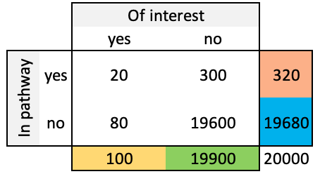

- Analysis with the hypergeometric/Fisher's exact test

## Gene Set Enrichment Analysis (GSEA)

- This method is based on ranking all genes in our dataset
- If the gene set is significantly affected in our experiment, then the genes in the set should tend to be at one end or the other of our ranking.
- The ranking method is arbitrary, but p-value and fold change are common choices.
- GSEA calculates an enrichment score based on the ranking, and then uses permutation to calculate a p-value for how significant the enrichment score is.

## GSEA - Calculate the enrichment score

- Ranking by Fold Change - unsorted logFC

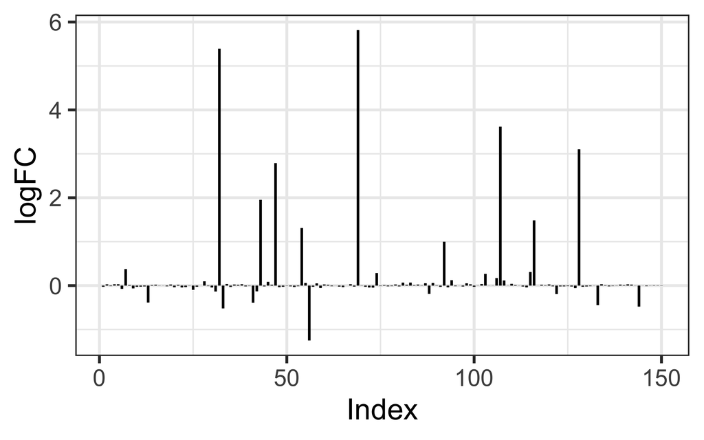

## GSEA - Calculate the enrichment score

- Ranking by Fold Change - sorted logFC, in decreasing order

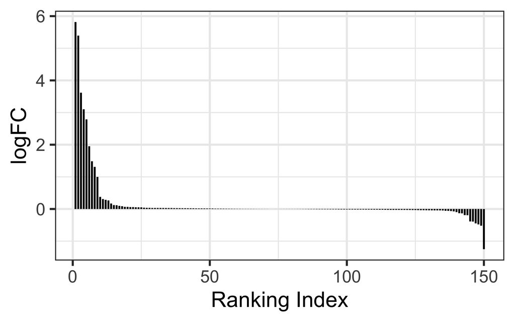

## GSEA - Calculate the enrichment score

- Identify genes in set

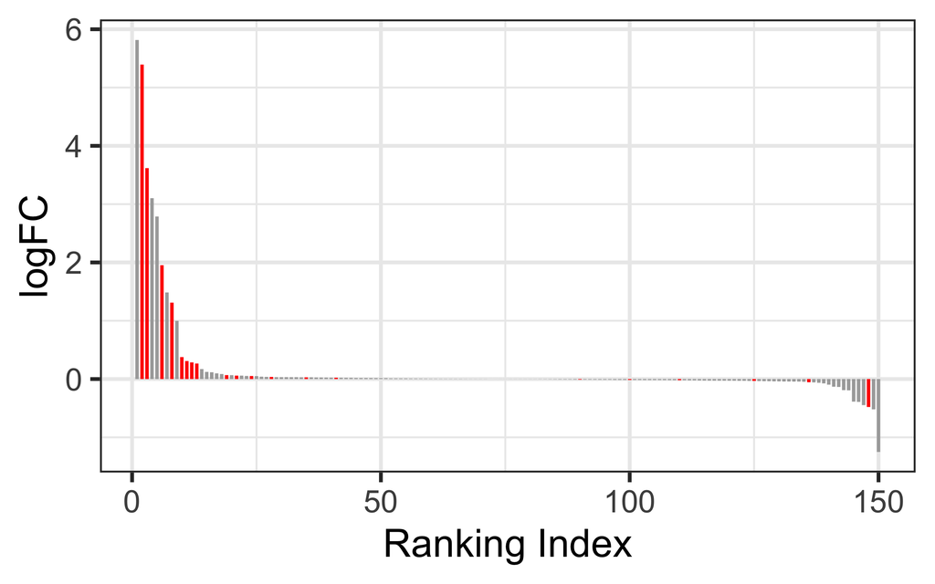

## GSEA - Calculate the enrichment score

- Calculate the enrichment score … start at 0 and an enrichment score of 0

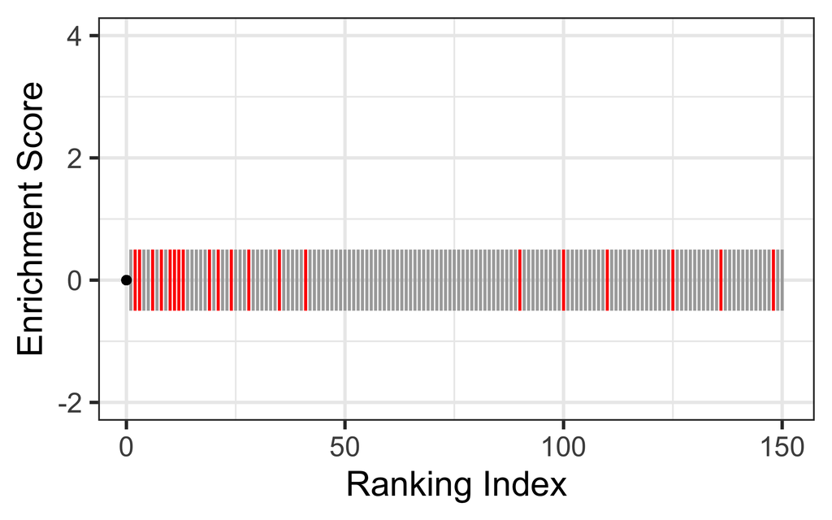

## GSEA - Calculate the enrichment score

- Walk along genes and calculate a cumulative score

[figure not shown]

## GSEA - Calculate the enrichment score

- A different gene set

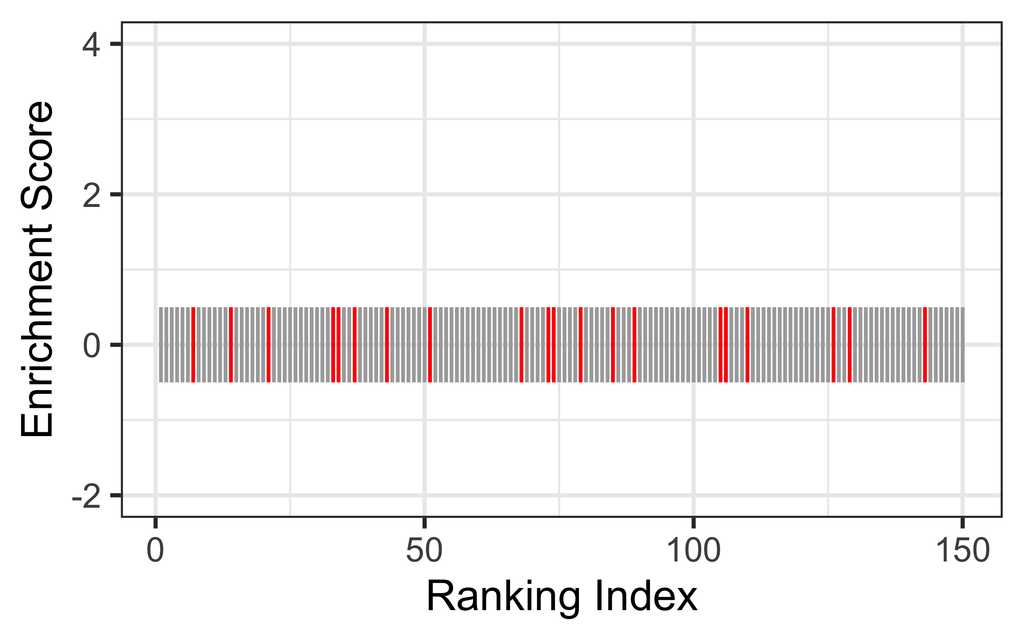

## GSEA - Calculate the enrichment score

- A different gene set

[figure not shown]

## GSEA - Estimate a p-value

- Randomly permute the ranking and recalculate the enrichment score, repeat many times.
- From a distribution of our permuted enrichment scores determine how likely our ES.

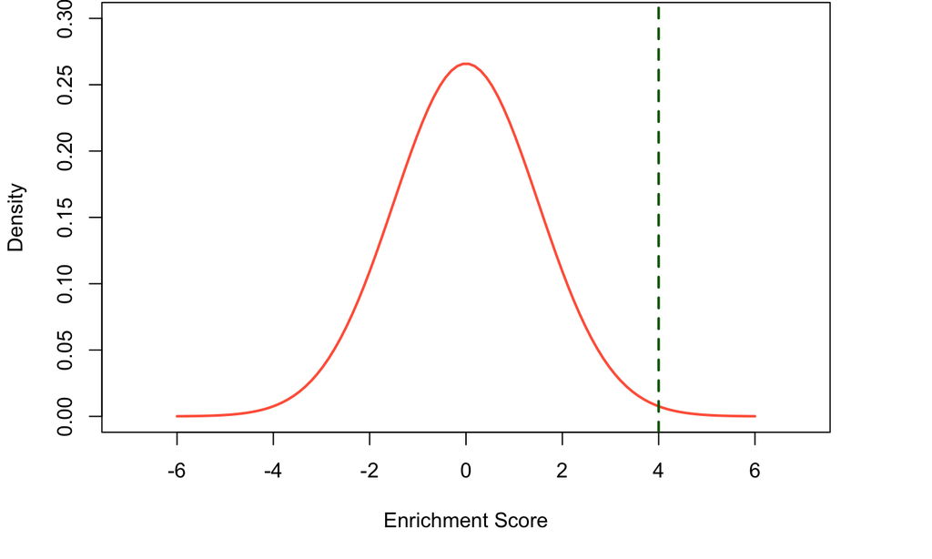

## Recap

Question: Do the differentially expressed genes tend to relate to specific pathways or ontological groups of genes?

For a given contrast and a given gene set.

Two methods:

- Over Representation Analysis (ORA)
  - split genes two ways: in pathway or not, of interest or not
  - Fisher exact test for ratio of 'pathway' odds in the two 'interest' classes
- Gene Set Enrichment Analysis (GSEA)
  - rank all genes using significance and/or logFC
  - compute enrichment score
  - compute its significance

Applicable to series of gene sets